# trajectory_analysis

## Trajectory analysis

To infer pseudotime dynamics, nuclei were ordered along a continuous trajectory based on principal component space, following approaches similar to Granja et al. (2020). For each feature type (ACR, motif, TF, gene activity), accessibility or activity values were modeled across pseudotime using generalized additive models (GAMs) with smooth terms. Predicted accessibility was standardized and used to capture dynamic changes across trajectories. Differential features were identified by fitting spline-based regression models and performing F-tests to detect significant variation across pseudotime, with false discovery rates (FDR < 0.05) used to determine statistical significance.

### **Inputs** (Required):

1. **`-script_dir`**  
   Path to the script directory downloaded from GitHub:  
   `Socrates2/utils/input_other_required_scripts_dir`
2. **`-soc_obj`**  
   (The *.atac.soc.qs2 object obtained from the **“Motif deviation score”** step in  
   [9. Motif analysis](http://htmlpreview.github.io/?https://github.com/yanhaidong1/Socrates2/blob/main/vignettes/motif_analysis.html))
3. **`-meta_fl`**  
   Optional if `-soc_obj` is used. Metadata file containing at least the cell names and their corresponding identity attributes. Cell identities can be annotated in *Option 5: generate the final UMAP plot with labeled cell identities* in [Step 5: Annotate Cell Identity](http://htmlpreview.github.io/?https://github.com/yanhaidong1/Socrates2/blob/main/vignettes/annotate_cell_identity.html). If you wish to use a custom metadata file, please ensure it includes a `cell_identity` column specifying the cell type for each cell, and a `celltype_color` column indicating the corresponding color for each cell type.
4. **`-soc_obj_svd`**  
   Optional if `-soc_obj` is used. Path to the RDS object (`*.atac.soc.qs2`) containing the dimension reduction results. This file is generated during [Step 3: Clustering](http://htmlpreview.github.io/?https://github.com/yanhaidong1/Socrates2/blob/main/vignettes/clustering.html).
5. **`-celltype_path`**  
   A string that defines the progression of cell types along a developmental trajectory. For example, if the dataset includes three cell types—`cell_type1`, `cell_type2`, and `cell_type3`—representing early, middle, and late stages respectively, the `-celltype_path` should be specified as: `-celltype_path cell_type1,cell_type2,cell_type3`.

### **Optional parameters** :

1. **`-feature`**  
   A feature string indicating which features (**Gene**, **TF**, **Motif**, or **ACR**) to include in the trajectory analysis. By default, all four features are analyzed. If users prefer to analyze a subset, they must specify at least one feature.
2. **`-soc_obj_gene_acc`**  
   Optional if `-soc_obj` is used. If the **Gene** or **TF** feature is selected, users must provide an RDS object containing gene accessibility data. This file (`*.atac.soc.qs2`) is generated in the *Calculate gene accessibility* step of [Step 4: Prepare Gene Accessibility](http://htmlpreview.github.io/?https://github.com/yanhaidong1/Socrates2/blob/main/vignettes/prepare_gene_accessibility.html).
3. **`-TF_fl`**  
   If the **TF** feature is selected, users must provide a transcription factor gene list file, which can be downloaded from the [PlantTFDB database](https://planttfdb.gao-lab.org/). The file should contain three columns: `TF_ID`, `Gene_ID`, and `Family`.
4. **`-motif_dev_fl`**  
   Optional if `-soc_obj` is used. If the **Motif** feature is selected, users must provide an smoothed motif deviation file. This file (`*.smoothed_motifs.txt`) is generated in the *Motif deviation score* step of [Step 9: Motif analysis](http://htmlpreview.github.io/?https://github.com/yanhaidong1/Socrates2/blob/main/vignettes/motif_analysis.html).
5. **`-ACR_sparse_fl`**  
   Optional if `-soc_obj` is used. If the **ACR** feature is selected, users must provide an ACR sparse file with Tn5 integration site. This file (`opt_peak_sorted.sparse`) is generated during [Step 8: Identify cell-type-specific peak](http://htmlpreview.github.io/?https://github.com/yanhaidong1/Socrates2/blob/main/vignettes/find_diff_markers.html).
6. **`-core`**  
   Number of cores to use for parallel analysis (Default: `1`)
7. **`-prefix`**  
   Prefix for output files (Default: `output`)
8. **`-TopACR_num`**  
   Number of top ACRs exhibiting the most dynamic changes along the trajectory. (Default: `10000`)
9. **`-open_equal_cellnum`**  
   Set to `yes` or `no` to enforce equal cell numbers across all cell types included in the trajectory analysis. (Default: `yes`)

**Outputs**  
1. step02_running_trajectory_analysis_dir/.trajectory.txt  
2. step02_running_trajectory_analysis_dir/.(Genes|TFs|Mt|ACR)_pt_sorted.txt  
3. step02_running_trajectory_analysis_dir/.(Genes|TFs|Mt|ACR).diffTestsQVALs.txt  
4. step02_running_trajectory_analysis_dir/.trajectory(Genes|TFs|Mt|ACR).pdf  
5. step02_running_trajectory_analysis_dir/*_PTplot.pdf

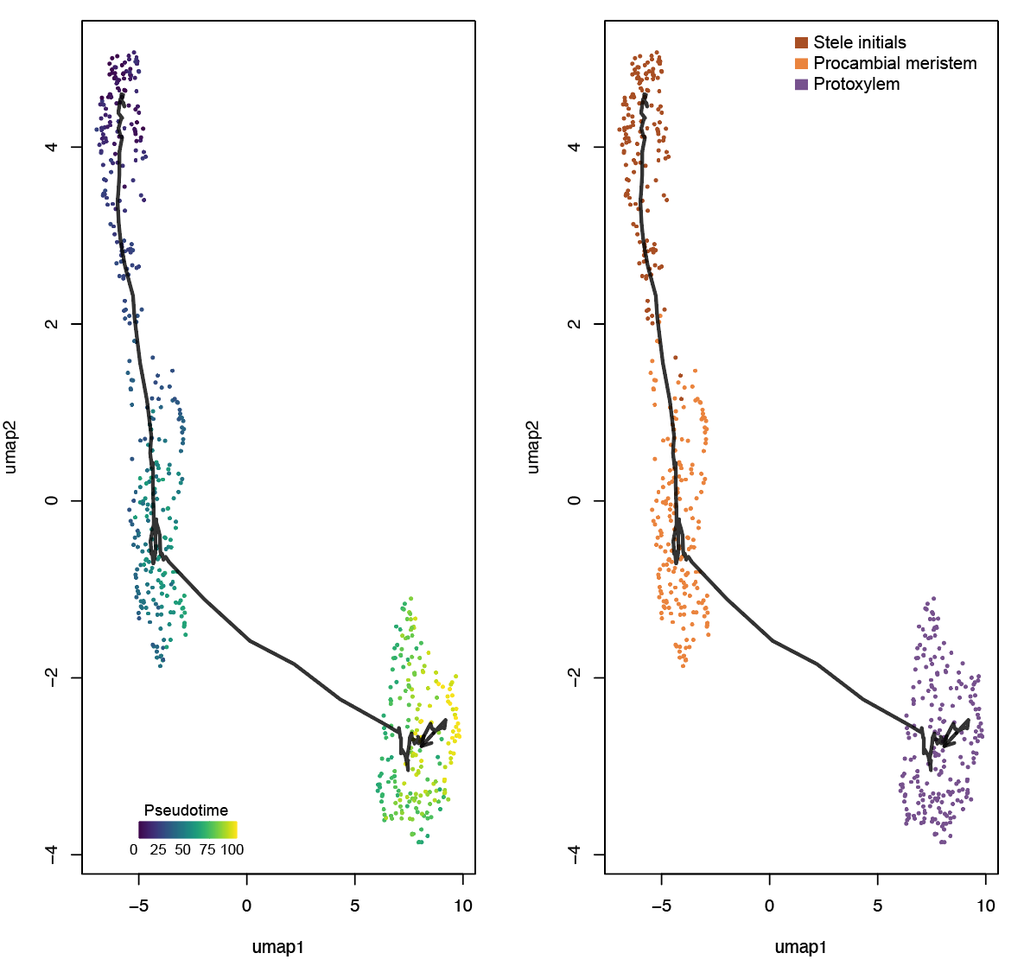

Figure 1: example of *_PTplot.pdf

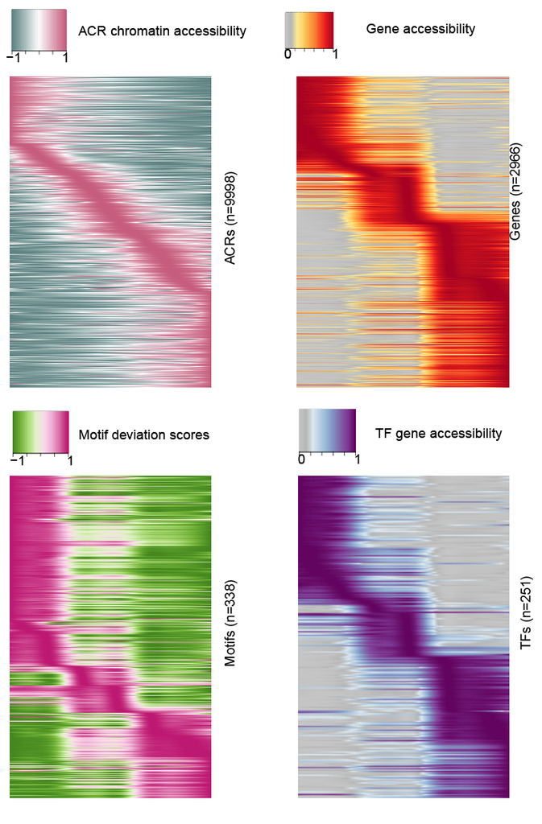

Figure 2: example of *.trajectory(Genes|TFs|Mt|ACR).pdf

### **Option 1: Perform analysis for all features (Gene, TF, Motif, or ACR)**:

**Running**:

```bash
python Socrates2/utils/trajectory.py
-script_dir Socrates2/utils/input_other_required_scripts_dir
-o output_dir
-soc_obj /Path/to/*.atac.soc.qs2
-celltype_path celltype1,celltype2,celltype3
-TF_fl /Path/to/*_TF_list.txt
-core 10
```

### **Option 2: Perform analysis for Gene feature**:

**Running**:

```bash
python Socrates2/utils/trajectory.py
-script_dir Socrates2/utils/input_other_required_scripts_dir
-o output_dir
-soc_obj /Path/to/*.atac.soc.qs2
-celltype_path celltype1,celltype2,celltype3
-feature Gene
-core 10
```

### **Option 3: Perform analysis for TF feature**:

**Running**:

```bash
python Socrates2/utils/trajectory.py
-script_dir Socrates2/utils/input_other_required_scripts_dir
-o output_dir
-soc_obj /Path/to/*.atac.soc.qs2
-celltype_path celltype1,celltype2,celltype3
-TF_fl /Path/to/*_TF_list.txt
-feature TF
-core 10
```

### **Option 4: Perform analysis for Motif feature**:

**Running**:

```bash
python Socrates2/utils/trajectory.py
-script_dir Socrates2/utils/input_other_required_scripts_dir
-o output_dir
-soc_obj /Path/to/*.atac.soc.qs2
-celltype_path celltype1,celltype2,celltype3
-feature Motif
-core 10
```

### **Option 5: Perform analysis for ACR feature**:

**Running**:

```bash
python Socrates2/utils/trajectory.py
-script_dir Socrates2/utils/input_other_required_scripts_dir
-o output_dir
-soc_obj /Path/to/*.atac.soc.qs2
-celltype_path celltype1,celltype2,celltype3
-feature ACR
-core 10
```